# Badawi Amin Muhammed

### Data Scientist • AI & ML Engineer • Research Data Analyst

# Building & Performing Neural Network Analysis in R with Torch

Badawi Amin Muhammed

2025-11-20

# INTRODUCTION

This project demostrates how to build and train a simple neural network using the torch package.

The torch package brings deep learning to R by providing bindings to the popular PyTorch library. This comprehensive project demonstrates how to build and train a simple neural network using torch in R.

#installation

```r
#install.packages("torch")
library(torch)
library(ggplot2)
#torch::install_torch()
```

#set seed for reproducibility

```r
set.seed(42)
```

# Generate training data: y = 3x + 2 + noise

```r
x<- torch_randn(100, 1)
y<- 3 * x + 2 + torch_randn(100, 1) * 0.3

#display the first few data points
head(data.frame(
  x = as.numeric(x$squeeze()),
  y = as.numeric(y$squeeze())
))
```

```
##            x           y
## 1  1.5389941  6.48198080
## 2  0.5420342  3.83502460
## 3 -0.2955945  0.52947181
## 4 -0.6785704  0.09556369
## 5 -0.5023355  0.29653335
## 6  2.5532901 10.54154968
```

# NEURAL NETWORK MODULE

Now we define the neural network architechture using torch’s module system:

# Define a simple feedforward neural network

```r
nnet <- nn_module (
      initialize = function() {
        #define layers
        self$layer1 <- nn_linear(1, 8)
        self$layer2 <- nn_linear (8, 1)
        },
      forward = function(x){
        #define forward pass
        x %>%
          self$layer1() %>% #first linear transfromation
          nnf_relu() %>%    #ReLU activation function
          self$layer2()     #second linear transformation
        },
      )
#instantiate the model
model<- nnet()

#dsiplay model structure
print(model)
```

```
## An `nn_module` containing 25 parameters.
##
## ── Modules ─────────────────────────────────────────────────────────────────────
## • layer1: <nn_linear> #16 parameters
## • layer2: <nn_linear> #9 parameters
```

# SET UP OPTIMIZER AND LOSS FUNCTION

The training process requires defining how the model will learn from the data:

we set up an adam optimizer with learning rate at 0.02

```r
optimizer <- optim_adam(model$parameters, lr=0.02)

#define loss function (MSE)
loss_fn <- nnf_mse_loss
```

# TRAINING LOOPS

store loss values for plotting

```r
loss_history <- numeric(300)

#Training loop
for (epoch in 1:300) {
  #set model to trainig mode
  model$train()

  #reset gradients
  optimizer$zero_grad()

  #forward pass
  y_pred <- model(x)

  #calculate loss
  loss <- loss_fn(y_pred, y)

  #backward pass
  loss$backward()

  #update parameters
  optimizer$step()

  #store loss for plots
  loss_history [epoch] <- loss$item()
}


# Visualize the training progress
#create a data frame for plotting
training_df <- data.frame (
  epoch = 1:300,
  loss = loss_history
)
```

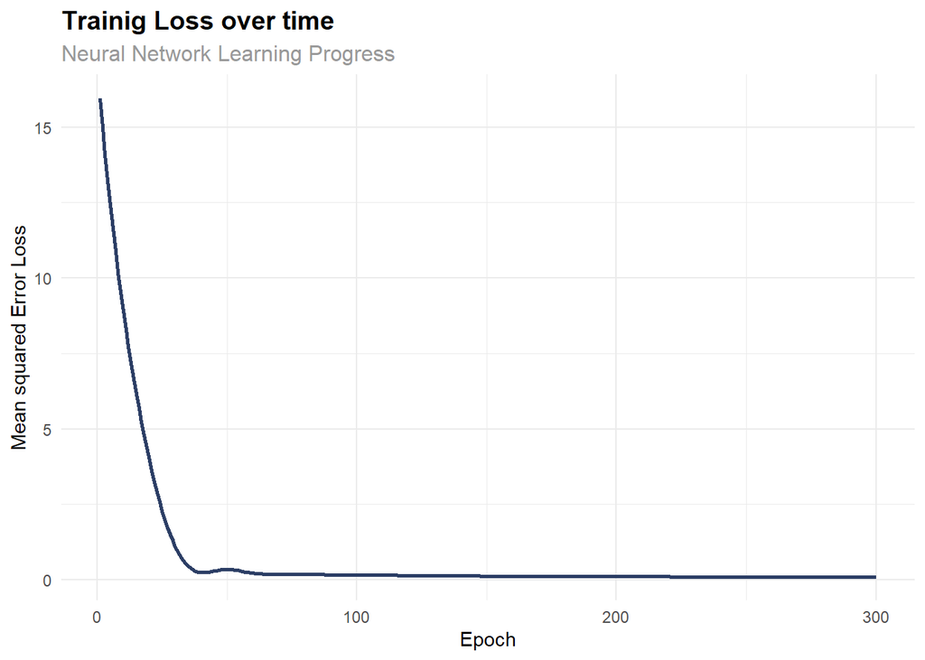

Trainig loss function

```r
#plotting training loss
ggplot(training_df, aes(x = epoch, y = loss)) +
  geom_line(color = "#2c3e65", size = 1)  +
  labs(
    title = "Trainig Loss over time",
    subtitle = "Neural Network Learning Progress",
    x = "Epoch",
    y = "Mean squared Error Loss"
    ) +
  theme_minimal() +
  theme(
    plot.title = element_text(size = 14, face = "bold"),
    plot.subtitle = element_text(size = 12, color = "gray60")
  )
```

# VISUALIZE THE RESULT

set model evaluation mode

```r
model$eval()

#generate predictions
with_no_grad({
  y_pred <- model(x)
})


#convert to Rvectors for plottin
x_np <- as.numeric(x$squeeze())
y_np <- as.numeric(y$squeeze())
y_pred_np <- as.numeric(y_pred$squeeze())

#create dataframe for ggplot
plot_df <- data.frame(
  x = x_np,
  y_actual = y_np,
  y_predicted = y_pred_np
  )
```

#create the plot

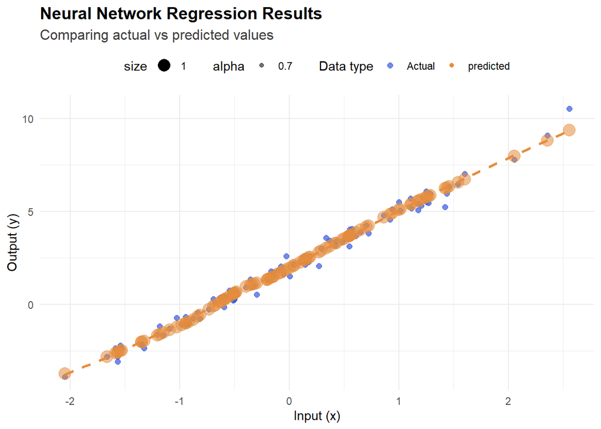

neural network plot

```r
ggplot(plot_df, aes(x=x)) +
  geom_point(aes(y = y_actual, color = "Actual"), alpha = 0.7, size = 2) +
  geom_point(aes(y = y_predicted, color = "predicted", alpha = 0.7, size = 1)) +
  geom_smooth(aes(y = y_predicted), method = "loess", se = FALSE, color = "#e88c3c", linetype = "dashed") +
  labs(
    title = "Neural Network Regression Results",
    subtitle = "Comparing actual vs predicted values",
    x = "Input (x)",
    y = "Output (y)",
    color = "Data type"
  ) +
  scale_color_manual(
    values = c("Actual" = "#3658dc", "predicted" = "#e48c3c")) +
  theme_minimal() +
  theme(
      plot.title = element_text(size = 14, face = "bold"),
      plot.subtitle = element_text(size = 12, color = "gray25"),
      legend.position = "top"
    )
```

# MODEL PERFORMANCE ANALYSIS

```r
mse <- mean((y_pred_np - y_np)^2)
rmse <- sqrt(mse)
mae <- mean(abs(y_pred_np - y_np))
r_squared <- cor(y_pred_np, y_np) ^2

#Create performance metrics
performance_summary <- data.frame(
                        metric = c("Mean Squared Error", "Root Mean Squared Error", "Mean Absolute Error", "R-Squared"),
                        value = c(mse, rmse, mae, r_squared)
)

print(performance_summary)
```

```
##                    metric      value
## 1      Mean Squared Error 0.09719032
## 2 Root Mean Squared Error 0.31175362
## 3     Mean Absolute Error 0.23808641
## 4               R-Squared 0.98831562
```